# Linear Regression in Vector-Matrix Form

A Concise and General Approach

Vladislav Morozov

## Introduction

#### Learning Outcomes

This lecture is about a vector-matrix approach to linear regression

By the end, you should be able to

- Represent linear regression in scalar, vector, and matrix forms
- Derive the explicit form of the OLS estimator

#### Textbook References

- Linear algebra refresher:
  - Appendix D in Wooldridge (2020)
  - Easier treatment with more examples: chapter 1-2 in Strang (2016)
  - Quicker discussion: Kaye and Wilson (1998)
- Vector treatment of linear regression: E1 (except E-1a) in Wooldridge (2020)

## Motivation

### Reminder: Multivariate Regression

#### Reminder: OLS Estimator

Ordinary Least Squares (OLS):
$$\begin{aligned}
(\hat{\beta}_1, \dots, \hat{\beta}_k) = \argmin_{b_1, b_2, \dots, b_k} \sum_{i=1}^N \left( Y_i - b_1 - b_2 X_{i2} - \dots - b_k X_{ik}\right)^2
\end{aligned}$$

#### Reminder: When is the OLS Estimator Defined?

OLS estimator well-defined if

1. No strict multicollinearity
2. Every $X_{ij}$ varies in sample for $j>1$

Remember: can always define OLS estimator *even if* $Y_i$ does *not* depend linearly on covariates. OLS is just a *method*

### Scalar Representation and Its Issues

#### Scalar Representation

**Definition 1** Linear regression model
$$Y_i = \beta_1 + \beta_2 X_{i2} + \beta_3 X_{i3} + \dots + \beta_k X_{ik} + U_i,$$
is said to be in *scalar* form.

“*Scalar*” means

- No matrices
- Every covariate is written out individually

#### Pros of Scalar Representation

Scalar representation used only when we care about the individual regressors

Usual case: when presenting estimated equations.

Example: regression of wages on education and experience:
$$\widehat{\log(wage)} = \underset{(0.094)}{0.284} + \underset{(0.032)}{0.092}\times Education + \dots$$
Standard errors in parentheses below the estimates

#### Cons of Scalar Representation

Scalar representation has downsides:

1. Unnecessarily long: if you just have “anonymous” $(X_{i2}, \dots, X_{ik})$, why bother writing them out?
2. No explicit formula for OLS estimator
3. Inconvenient to program

#### Is There a Solution?

Yes! The *vector*
$$y_i = \bbeta_i'\bx_i + U_{i}$$
and *matrix* forms
$$\bY = \bX\bbeta + \bu$$

This lecture is about working with these forms and using them to derive the OLS estimator.

## Vector and Matrix Forms of Regression

### Vector Form

#### Model

Our model in this lecture:
$$\begin{aligned}
Y_{i} & = \beta_1 X_{i1} + \dots + \beta_k X_{ik} + U_{i}\\
& = \sum_{j=1}^k \beta_k X_{ik} + U_{i}
\end{aligned}$$

Here $X_{i1}$ may be $X_{i1} = 1$ if you want to include an intercept

#### Vector of Covariates and Coefficients

Our first problem: writing out $X_{i1}, \dots, X_{ik}$ every time

Why not combine the covariates into a single vector $\bX_i$ and coefficients into a vector $\bbeta$? Combine them into column $k$-vectors ($k\times 1$ matrices):

$$\bX_i = \begin{pmatrix}
X_{i1} \\
X_{i2} \\
\vdots \\
X_{ik}
\end{pmatrix}, \quad \bbeta = \begin{pmatrix}
\beta_1 \\
\beta_2 \\
\vdots \\
\beta_k
\end{pmatrix}$$

#### Reminder: Transposition

Recall the transposition operator:
$$\bX_i = \begin{pmatrix}
X_{i1} \\
X_{i2} \\
\vdots \\
X_{ik}
\end{pmatrix}, \quad \bX'_i = \begin{pmatrix} X_{i1}, X_{i2}, \dots, X_{ik} \end{pmatrix}$$
$\bX'_i$ is read “*$\bX_i$ transpose*”. Sometimes also labeled as $\bX_i^T$.

#### Combining $\bX_i$ and $\bbeta$

Need to combine $\bX_i$ and $\bbeta$ to obtain $\sum_{j=1}^k \beta_k X_{ik}$

Using rules of matrix multiplication, obtain exactly
$$\bX_i'\bbeta = \sum_{j=1}^k \beta_k X_{ik}$$
Note that $\bX_i'\bbeta = \bbeta'\bX_i$ (why?)

Vectors are *column* vectors by default; we will transpose when necessary — standard approach. Careful with Wooldridge (2020): he mixes rows and column vectors to avoid transposes.

#### Vector Form of Linear Regression

Can now combine $\bX_i'\bbeta$ with $U_i$ to get $Y_i$

**Definition 2** Linear regression model
$$Y_i = \bX_i'\bbeta + U_i$$
is said to be in *vector* form.

### Matrix Form

#### Stacking Observations

Vector form — convenient representation of model for *a single observation $i$*:
$$Y_i = \bX_i'\bbeta + U_i$$

What if we want to represent the model for the *whole sample*?

#### Tabular Data Form

Why and how? Think of how we store data, e.g., in `pandas`:

```python
import pandas as pd
import statsmodels.api as sm

credit_card_df = sm.datasets.ccard.load_pandas().data
credit_card_df.head(2)
```

|  | AVGEXP | AGE | INCOME | INCOMESQ | OWNRENT |
| --- | --- | --- | --- | --- | --- |
| 0 | 124.98 | 38.0 | 4.52 | 20.4304 | 1.0 |
| 1 | 9.85 | 33.0 | 2.42 | 5.8564 | 0.0 |

Each row is an observation $i$, variables stored in different columns — data as a *table*

[Link](https://www.statsmodels.org/stable/datasets/generated/ccard.html) to the docs on the `ccard` dataset

#### Stacking Observations I

(Flat) tabular form

- Usually convenient in practice
- Also convenient in theory!

To replicate, put outcomes in a *vector* $\bY$:
$$\bY = \begin{pmatrix}
Y_1\\
\vdots\\
Y_N
\end{pmatrix}$$

#### Stacking Observations II

Recall vector form: $Y_i = \bX_i'\bbeta + U_i$. Stacking left hand sides also stacks right hand sides:
$$\begin{pmatrix}
Y_1\\
\vdots\\
Y_k
\end{pmatrix} = \begin{pmatrix}
\bX_1'\bbeta + U_1\\
\vdots \\
\bX_N'\bbeta + U_N
\end{pmatrix}
\tag{1}$$
Here $N$ is the number of observations (rows)

#### Matrix of Covariates I

Next, define the $N\times k$ matrix $\bX$ (note: no $i$ index)
$$\bX = \begin{pmatrix}
\bX_1'\\
\bX_2'\\
\vdots\\
\bX_N'
\end{pmatrix} = \begin{pmatrix}
X_{11} & X_{12} & \cdots & X_{1k} \\
X_{21} & X_{22} & \cdots & X_{2k}\\
\vdots & \vdots & \ddots & \vdots\\
X_{N1} & X_{N2} & \cdots & X_{Nk}
\end{pmatrix}$$

#### Matrix of Covariates II

$\bX$ — precisely a table of covariates:

1. A row is an individual observation: the $i$th row — values of covariates for the $i$ observation (corresponds to $\bX_i$!)
2. A column is all observations of a given variable: $j$th column is $(X_{1j}, X_{2j}, \dots X_{Nj})$

`statsmodels` often uses the term `exog` for $\bX$. `scikit-learn` simply uses `X`

#### Vector of Residuals

Define the column vector $\bU$ of residuals through its transpose
$$\bU' = \begin{pmatrix}
U_1 & U_2 & \dots & U_n
\end{pmatrix}$$

Books and articles often define column vectors using their transposes — this saves vertical space

#### Splitting The Right-Hand Side

Can go back to Equation 1. Using matrix multiplication rules and $\bU$, can write
$$\begin{pmatrix}
\bX_1'\bbeta + U_1\\
\vdots \\
\bX_N'\bbeta + U_N
\end{pmatrix} = \begin{pmatrix}
\bX_1'\bbeta \\
\vdots \\
\bX_N'\bbeta
\end{pmatrix} + \bU = \bX\bbeta + \bU$$

Check this! Write out each part of the above equalities in detail

#### Matrix Form of Linear Regression

Matrix form — combine all sample points into one equation. Solves our third problem: convenient form for computers

## The OLS Estimator

### Derivation

#### Estimation Problem

Our last remaining goal: convenient expression for the OLS estimator $\hat{\bbeta}$:
$$\hat{\bbeta} = (\hat{\beta}_1, \hat{\beta}_2, \dots, \hat{\beta}_k)'$$

Recall that $\hat{\bbeta}$ is defined through optimization
$$\hat{\bbeta} = \argmin_{b_1, b_2, \dots, b_k}\sum_{i=1}^N \left( Y_i - \sum_{j=1}^k b_j X_{ij}\right)^2$$

#### Approach to Optimization

Ojective function is differentiable in $(b_1, \dots, b_k)$

$\Rightarrow$ our strategy:

1. Differentiate with respect to the arguments. Set the derivative equal to 0 (first order conditions)
2. Hope that
   - There is a unique solution to the first order conditions
   - The solution actually minimizes the function (instead of maximizing or being a saddle point)

#### Derivative With Respect to $b_j$

Derivative with respect to $b_j$ is given by
$$\begin{aligned}
& -2\sum_{i=1}^N X_{ij} \left(Y_i - \sum_{l=1}^k b_l X_{il}\right)\\
& = -2\sum_{i=1}^N X_{ij} \left(Y_i - \bX_i'\bb\right)
\end{aligned}$$

#### First Order Conditions (FOCs)

Any optimizer $\hat{\bbeta} = (\hat{\beta}_1, \dots, \hat{\beta}_k)$ must satisfy the FOC system
$$\begin{cases}
-2\sum_{i=1}^N X_{i1} \left(Y_i - \bX_i'\hat{\bbeta} \right) = 0\\
\vdots \\
-2\sum_{i=1}^N X_{ik} \left(Y_i - \bX_i'\hat{\bbeta} \right) = 0
\end{cases}$$

In words, all partial derivatives of the objective function must be zero at $\hat{\bbeta}$

#### Normal Equations

Notice that (check this!) that FOCs can be compactly written as
$$\bX'(\bY - \bX\hat{\bbeta}) = 0
\tag{2}$$

**Definition 4** Equation 2 is called the *normal equations*.

#### Normal Equations as a Linear System

Can write Equation 2 as
$$(\bX'\bX)\hat{\bbeta} = \bX'\by$$

A standard system linear system of equations of the form $\bA\hat{\bbeta} = \bc$ for $\bA = (\bX'\bX)$ and $\bc= \bX'\by$

- $\bX'\bX$ is a $k\times k$ matrix (what are its elements?)
- System has $k$ unknowns

#### Solving the Normal Equations

$k$ equations in $k$ unknowns — systems has 1 or infinitely many solutions, depending on rank of $\bX'\bX$

- Maximum rank = unique solution
- Less than maximum rank = infinitely many solutions

Recall: if $\bA$ is a square matrix with maximal rank, $\bA^{-1}$ exists

#### Objective Function and $\bX'\bX$

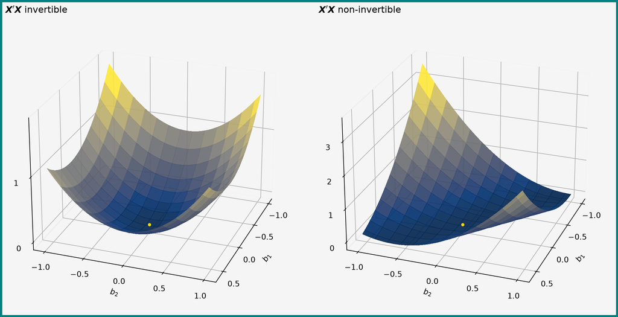

#### Vector Formula for OLS Estimator

**Proposition 1 (OLS Estimator Formula)** Let $\bX'\bX$ have rank $k$. Then $(\bX'\bX)^{-1}$ exists and the OLS estimator is given by
$$\hat{\bbeta} = (\bX'\bX)^{-1}\bX'\bY$$

Exercise: check that the above formula agrees with the simple formula involving sample covariance and variance when $k=2$ and $X_{i1}=1$

### Extra Material

#### Vector and Matrix Forms of Objective Function

Can do the derivation more efficiently:
$$\begin{aligned}
& \sum_{i=1}^N \left( Y_i - \sum_{j=1}^k b_j X_{ij}\right)^2 = \sum_{i=1}^N \left( Y_i -\bX_i'\bb\right)^2\\
& = (\bY-\bX\bbeta)'(\bY-\bX\bb) = \bY'\bY - 2\bY'\bX\bb + \bb'\bX'\bX\bb
\end{aligned}$$
where $\bb=(b_1, \dots, b_k)'$

#### Matrix First Order Conditions

You can differentiate with respect to the whole vector $\bbeta$, see [Wikipedia](https://en.wikipedia.org/wiki/Matrix_calculus#Scalar-by-vector)

Vector form of first order condition
$$\dfrac{\partial (\bY'\bY - 2\bY'\bX\bb + \bb'\bX'\bX\bb)}{\partial \bb} = -2\bX'\bY + 2\bX'\bX\bb$$

Setting the derivative equal to zero and rearranging again gives
$$\bX'\bX\hat{\bbeta} = \bX'\by$$

## Recap and Conclusions

#### Recap

In this lecture we

1. Introduced vector and matrix forms of linear regression
2. Derived the OLS estimator in vector and matrix forms

#### Next Questions

1. When is $\bX'\bX$ invertible (= full rank?)
2. What are the statistical properties of $\hat{\bbeta}$?
3. How to extend the vector approach to other familiar estimators — such as IV with several covariates and instruments.

#### References

Kaye, Richard, and Robert Wilson. 1998. *Linear Algebra*. Oxford Science Publications. Oxford Univ. Press.

Strang, Gilbert. 2016. *Introduction to Linear Algebra*. 5th edition. Cambridge press.

Wooldridge, Jeffrey M. 2020. *Introductory Econometrics: A Modern Approach*. Seventh edition. Cengage.

[figure not shown]